# Looking into Inter-Variable Relationships and Classification with Five Predictor Models in the Bank Marketing Dataset to Determine Subscribed Status of Clients

Thomas Johnson III

November 29, 2021

# Introduction

This project will be focused on analyzing data to view the relationships between select features of a dataset and using a selection of features for the purpose of developing a classification model. The origin of the data,called the Bank Marketing Data Set, is from the UCI Machine Learning repository where it may be downloaded. The original endeavor concerning the Bank Marketing Data Set is (Moro et al., 2014). More relevant points of interest concerning the dataset may be found at the UCI data repository as well as (Moro et al., 2014) article.

The Bank Marketing Data Set has 21 variables that can be utilized for data analysis and predictive modeling. The Bank Marketing Data Set can be found at [UCI](https://archive.ics.uci.edu/ml/datasets/bank+marketing) and is available for download.

## Drive Behind the Project

With data becoming more plentifully available, it has become ever more crucial to be able extract relevant data for a task and utilize the data effectively. Data science, machine learning, statistics, all three of these interweaving fields have become ever more valuable. In utilizing this dataset, the aim is be able to produce utilizable classification models under the constraints of the variables provided in Research Question 2. With businesses, public entities, and other organizations able to establish pipelines and cyberinfrastructure to amass, transfer, and process humongous amounts of data there is a natural goal to be able to utilize the data effectively. This requires narrowing down the features where there may be hundreds or thousands of features present. Additionally, this can also mean working with limited datasets in various contexts considering that data collection in and of itself is an expensive process to undertake in regard to monetary assets, time and other resources. This endeavor seeks to address two research questions to culminate in the production of machine learning models with the aim of being reliable means of identifying the y variable that will be established in researhc question 2.

```r
library(easypackages) #Load multiple packages at once
```

```r
libraries("mice","tidyverse","naniar",
          "boot", "car", "doSNOW",
          "randomForest", "foreach",
          "GGally",
          "corrplot", "data.table", "MASS","vcd",
          "caret")
```

Beginning by loading the data in:

```r
bank_data <- read.csv("./bank_dataset_without_semicolons.csv")
#write.csv(x=bank_data, file="./bank_dataset_without_commas.csv")
```

# Exploratory Data Analysis

## Dimensions of the data

First finding the quanitity of instances in the dataset:

```r
print(nrow(bank_data))
```

```
## [1] 4119
```

There are 4119 instances present in the data.

Next is finding the quantity of variables that are present within the dataset:

```r
bank_data <- bank_data %>% rename(., subscribed = y)
print(names(bank_data))
```

```
##  [1] "X"              "age"            "job"            "marital"
##  [5] "education"      "default"        "housing"        "loan"
##  [9] "contact"        "month"          "day_of_week"    "duration"
## [13] "campaign"       "pdays"          "previous"       "poutcome"
## [17] "emp.var.rate"   "cons.price.idx" "cons.conf.idx"  "euribor3m"
## [21] "nr.employed"    "subscribed"
```

```r
print(length(names(bank_data)))
```

```
## [1] 22
```

There are 21 variables capable in the dataset. The reason why is that the variable ‘X’ is literally the index of each instance.

Printing the first ten instances of the data to get a glance into it:

```r
head(bank_data, 10)
```

```
##     X age          job  marital           education default housing    loan
## 1   1  30  blue-collar  married            basic.9y      no     yes      no
## 2   2  39     services   single         high.school      no      no      no
## 3   3  25     services  married         high.school      no     yes      no
## 4   4  38     services  married            basic.9y      no unknown unknown
## 5   5  47       admin.  married   university.degree      no     yes      no
## 6   6  32     services   single   university.degree      no      no      no
## 7   7  32       admin.   single   university.degree      no     yes      no
## 8   8  41 entrepreneur  married   university.degree unknown     yes      no
## 9   9  31     services divorced professional.course      no      no      no
## 10 10  35  blue-collar  married            basic.9y unknown      no      no
##      contact month day_of_week duration campaign pdays previous    poutcome
## 1   cellular   may         fri      487        2   999        0 nonexistent
## 2  telephone   may         fri      346        4   999        0 nonexistent
## 3  telephone   jun         wed      227        1   999        0 nonexistent
```

[output cut: 18 more lines]

## Finding Missing Data

Does your dataset contain missing values? Which variables contain missing values?

```r
bank_data[bank_data =="unknown"]<-NA # A common way to denote missing
#values in the data is to use "unknown" string
```

```r
print(bank_data %>% summarise_all(funs(sum(is.na(.)))))
```

```
##   X age job marital education default housing loan contact month day_of_week
## 1 0   0  39      11       167     803     105  105       0     0           0
##   duration campaign pdays previous poutcome emp.var.rate cons.price.idx
## 1        0        0     0        0        0            0              0
##   cons.conf.idx euribor3m nr.employed subscribed
## 1             0         0           0          0
```

```r
#Total count of missing values throughout the data frame.
```

We can observe that for the job status variable there are 39 missing values, for the marital status variable there are 11 missing values, for the education status variable there are 167 missing values, for the default variable there are 803 missing values, for the housing vaariable there are 105 missing values, for the loan variable there are 105 missing values.

```r
print(sum(bank_data %>% summarise_all(funs(sum(is.na(.))))) )
```

```
## [1] 1230
```

Now we can observe there are 1230 missing values across all variables in the dataset.

A visualization of these missing values can assist:

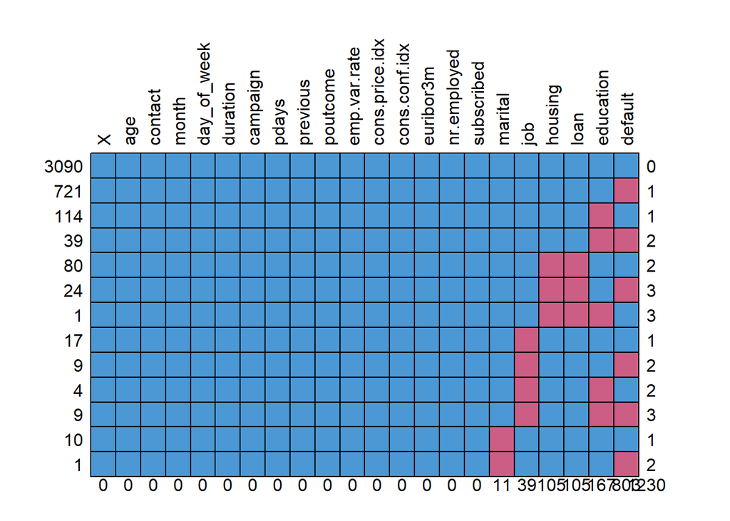

```
##      X age contact month day_of_week duration campaign pdays previous poutcome
## 3090 1   1       1     1           1        1        1     1        1        1
## 721  1   1       1     1           1        1        1     1        1        1
## 114  1   1       1     1           1        1        1     1        1        1
## 39   1   1       1     1           1        1        1     1        1        1
## 80   1   1       1     1           1        1        1     1        1        1
## 24   1   1       1     1           1        1        1     1        1        1
## 1    1   1       1     1           1        1        1     1        1        1
## 17   1   1       1     1           1        1        1     1        1        1
## 9    1   1       1     1           1        1        1     1        1        1
## 4    1   1       1     1           1        1        1     1        1        1
## 9    1   1       1     1           1        1        1     1        1        1
## 10   1   1       1     1           1        1        1     1        1        1
## 1    1   1       1     1           1        1        1     1        1        1
##      0   0       0     0           0        0        0     0        0        0
```

[output cut: 30 more lines]

```r
md.pattern(bank_data, rotate.names = T)
```

The above plot displays patterns of missing data. For example, one instance in the data is missing values for marital status and default status. Another 10 instances are only missing a value for the marriage variable. This plot helps visualize points of interest concerning the missing data, and the quantity of instances affected when managing the missing data for each variable or group of variables.

## Research Questions for the Data

Now to break down the research questions for the data that will be explored and tested.

## Research Question 1

What is the relationship between job/marital status and default status?

$H_{0}$: No relationship exists amongst the variables.

$H_{a}$: A relationship exists amongst at least two of the variables.

## Research Question 1 Variables:

Job status: What employment the client had (Dua and Graff, 2019).

Marital status: If the client was married, divorced (which also includes those who spouse has passed away) or single (Dua and Graff, 2019).

### Research Question 1 Response:

Default status: If the client has defaulted on their credit (Dua and Graff, 2019).

### Research Question 1 Missing Values:

Missing values for research question 1:

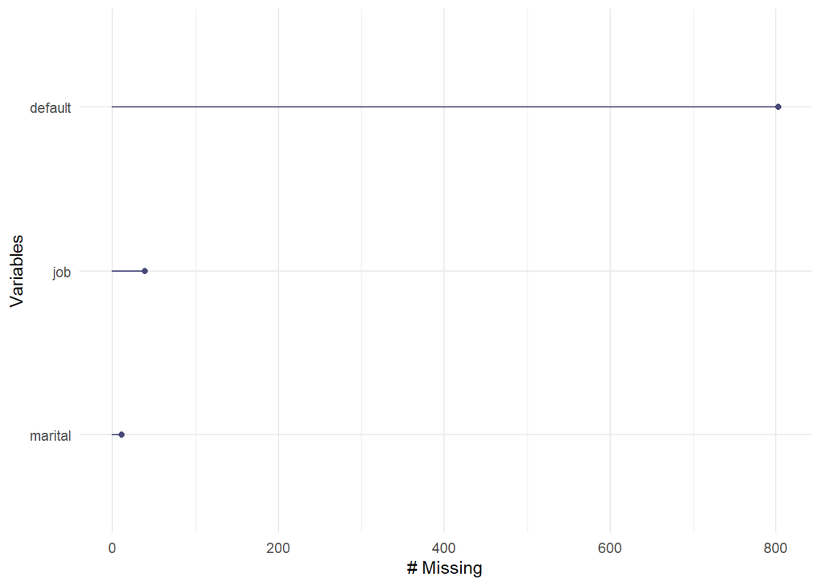

```r
categorical_missing.plot.object <- bank_data %>%
  dplyr::select(default, job, marital) %>% gg_miss_var()
print(categorical_missing.plot.object)
```

There are 39 missing values for the job variable.

There are 11 missing values for the marital variable.

There are 803 missing values for the default variable.

### Distribution of Response Variable for Research Question 1

Response variable distribution for research question 1

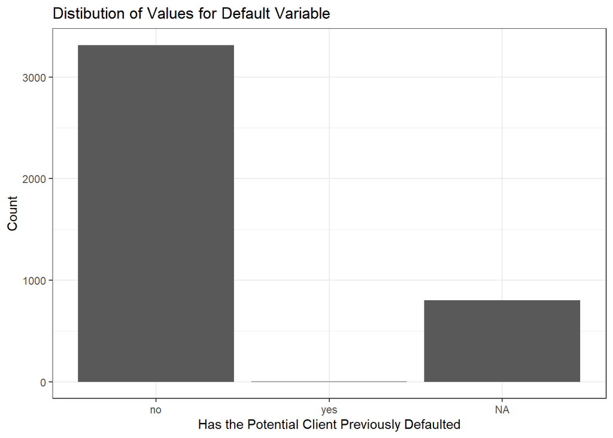

```r
bank_data %>%
  dplyr::select(default) %>%
  ggplot(aes(x=factor(default))) +
  geom_bar() +
  theme_bw() +
  xlab("Has the Potential Client Previously Defaulted") +
  ylab("Count") + ggtitle("Distibution of Values for Default Variable") +
  scale_x_discrete()
```

We can see most of the values for default are ‘no’, followed by missing values, or ‘NA’, then ‘yes.’

## Research Question 2

Can emp.var.rate, loan, default, education, campaign and previous.contact (to be substituted for pdays to avoid issues with missing values) be used to build a sufficient model to predict y, where y is whether the client has agreed to a term deposit subscription (classification)?

$H_{0}$: None of the variables will be able to be used to build a sufficient model to predict y.

$H_{a}$: At least one of the variables will be able to be used to build a sufficient model to predict y.

### Research Question 2 Variables:

emp.var.rate: Measure of the employment variation rate (Dua and Graff, 2019).

loan: The client currently possesses a personal loan (Dua and Graff, 2019).

default: If the client has defaulted on their credit (Dua and Graff, 2019).

education: The education status or level of the clients (Dua and Graff, 2019).

campaign: Quantity of attempts to reach out to client for the marketing campaign this data was collected within (Dua and Graff, 2019).

previous.contact: If the client was previously contacted from a marketing campaign preceding the one this data was collected in. Produced from utilizing data wrangling techniques on the pdays variable.

### Research Question 2 Variables:

y or subscribed: The binary outcome of whether the client has accepted a subscription for the term deposit product (Dua and Graff, 2019).

### Research Question 2 Missing Values:

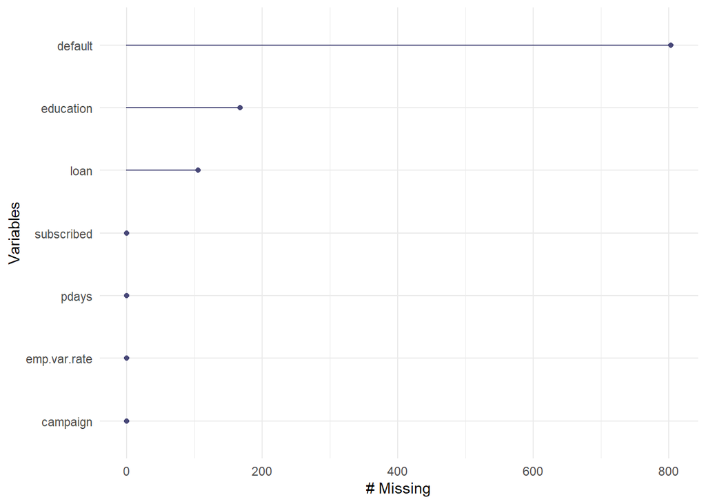

```r
predictor_var_missing.plot.object <- bank_data %>%
  dplyr::select(emp.var.rate, loan, default, education, campaign, pdays, subscribed) %>%
  gg_miss_var()
print(predictor_var_missing.plot.object)
```

There are 803 missing values for the default variable.

There are 167 missing values for the education variable.

There are 105 missing values for the loan variable.

The remaining variables of pdays, emp.var.rate, campaign, subscribed have no missing values.

### Research Question 2 Response Variable Distribution

Response variable distribution for research question 2

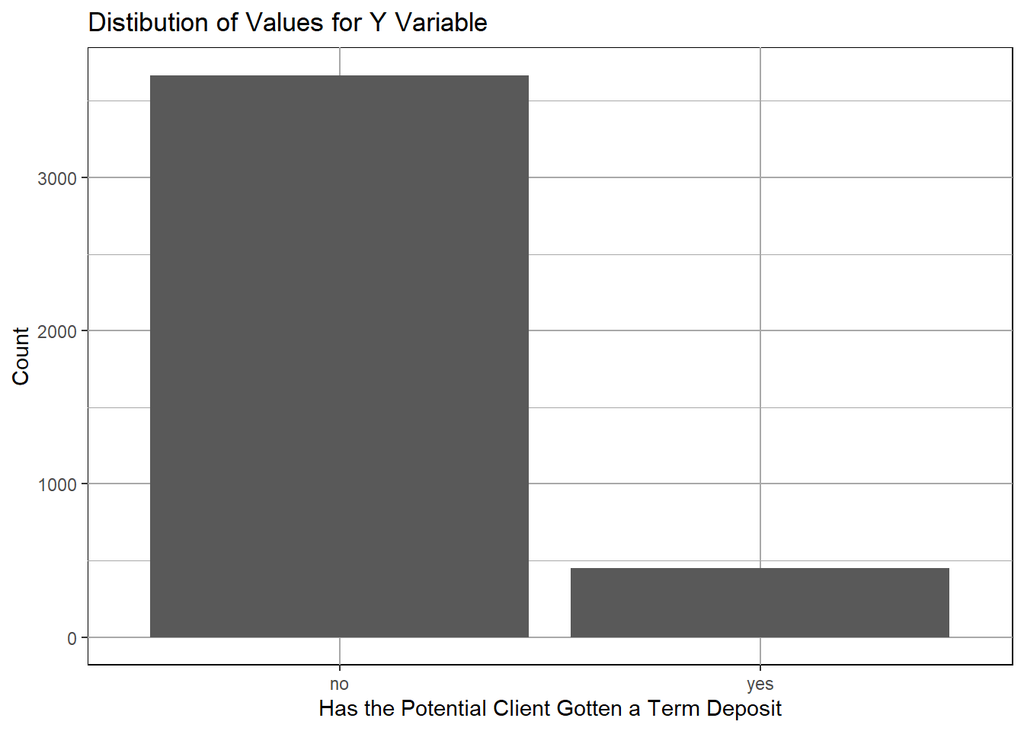

```r
bank_data %>%
  dplyr::select(subscribed) %>%
  ggplot(aes(x=factor(subscribed))) +
  geom_bar() +
  theme(panel.background =
          element_rect(fill="white", color="black"),
        panel.grid = element_line(colour = "darkgray")) +
  xlab("Has the Potential Client Gotten a Term Deposit") +
  ylab("Count") +
  ggtitle("Distibution of Values for Y Variable")
```

We can see that the majority class is ‘no’ and the minority class is ‘yes’ and subscribed status classes are heavily imbalanced.

```r
options(digits =3)
```

## Glimpsing Data

Performing a quick glimpse of the data before data cleaning and wrangling.

```r
glimpse(bank_data)
```

```
## Rows: 4,119
## Columns: 22
## $ X              <int> 1, 2, 3, 4, 5, 6, 7, 8, 9, 10, 11, 12, 13, 14, 15, 16, ~
## $ age            <int> 30, 39, 25, 38, 47, 32, 32, 41, 31, 35, 25, 36, 36, 47,~
## $ job            <chr> "blue-collar", "services", "services", "services", "adm~
## $ marital        <chr> "married", "single", "married", "married", "married", "~
## $ education      <chr> "basic.9y", "high.school", "high.school", "basic.9y", "~
## $ default        <chr> "no", "no", "no", "no", "no", "no", "no", NA, "no", NA,~
## $ housing        <chr> "yes", "no", "yes", NA, "yes", "no", "yes", "yes", "no"~
## $ loan           <chr> "no", "no", "no", NA, "no", "no", "no", "no", "no", "no~
## $ contact        <chr> "cellular", "telephone", "telephone", "telephone", "cel~
## $ month          <chr> "may", "may", "jun", "jun", "nov", "sep", "sep", "nov",~
## $ day_of_week    <chr> "fri", "fri", "wed", "fri", "mon", "thu", "mon", "mon",~
## $ duration       <int> 487, 346, 227, 17, 58, 128, 290, 44, 68, 170, 301, 148,~
## $ campaign       <int> 2, 4, 1, 3, 1, 3, 4, 2, 1, 1, 1, 1, 2, 2, 2, 2, 6, 4, 2~
## $ pdays          <int> 999, 999, 999, 999, 999, 999, 999, 999, 999, 999, 999, ~
## $ previous       <int> 0, 0, 0, 0, 0, 2, 0, 0, 1, 0, 0, 0, 0, 0, 0, 0, 0, 0, 0~
## $ poutcome       <chr> "nonexistent", "nonexistent", "nonexistent", "nonexiste~
## $ emp.var.rate   <dbl> -1.8, 1.1, 1.4, 1.4, -0.1, -1.1, -1.1, -0.1, -0.1, 1.1,~
## $ cons.price.idx <dbl> 92.9, 94.0, 94.5, 94.5, 93.2, 94.2, 94.2, 93.2, 93.2, 9~
## $ cons.conf.idx  <dbl> -46.2, -36.4, -41.8, -41.8, -42.0, -37.5, -37.5, -42.0,~
## $ euribor3m      <dbl> 1.313, 4.855, 4.962, 4.959, 4.191, 0.884, 0.879, 4.191,~
## $ nr.employed    <dbl> 5099, 5191, 5228, 5228, 5196, 4964, 4964, 5196, 5196, 5~
## $ subscribed     <chr> "no", "no", "no", "no", "no", "no", "no", "no", "no", "~
```

We can see the variables of interest are either integer, double, or characters.

## Data Cleaning and Data Wrangling

First step in data cleaning will be to get rid of the indices variable ’X" as it contributes nothing to the analysis as it is the index. The variable “duration” is also removed as it is indicated in the documentation of the dataset to be highly correlated with “y.”

```r
bank.2 <- bank_data %>% dplyr::select(.,-c(X,duration))
```

Checking the variables to make sure “X” was removed:

```r
print(names(bank.2))
```

```
##  [1] "age"            "job"            "marital"        "education"
##  [5] "default"        "housing"        "loan"           "contact"
##  [9] "month"          "day_of_week"    "campaign"       "pdays"
## [13] "previous"       "poutcome"       "emp.var.rate"   "cons.price.idx"
## [17] "cons.conf.idx"  "euribor3m"      "nr.employed"    "subscribed"
```

```r
bank.2.pdays.unaltered = bank.2
```

## Addressing Missing Values

For pdays, there are repeat entries of 999. This is to indicate that the prospective client was not contacted before within a previous direct marketing campaign by the bank. For the summary statistics, we convert each 999 to `NA`, create a new variable previous.contact as a factor to indicate if previous contact with the client was made, then proceed to calculate the summary statistics. Otherwise, the distribution for the pdays variable would be skewed to the right heavily if we calculated its summary statistics and highly misleading. The for pdays is not technically missing, in so much that the format in the dataset is not appropriately captured.

For more accurate details as to whether a potential client was previously contacted, we create the previous.contact variable. It is created using the value 999 from pdays to determine if a potential client was previously contacted or not, and will present less issues than working directly with pdays for predictive modeling later. Although we lose the data on how long ago previous contact may have occurred, the previous.contact variable preserves the crucial information on whether a client was previously contacted without producing highly skewed distributions in the data.

For the categorical variables of loan, job, marital and default, we have have over 800 missing values. We will use `na.omit` like methods to ensure that these missing values do not jeopardize calculations

```r
# Using NA values to fill in for missing data.
bank.2 = bank.2 %>%
  mutate(previous.contact = ifelse(pdays == 999, 0, 1),
         previous.contact = factor(previous.contact),
         pdays = ifelse(pdays == 999, NA, pdays))
```

## Significance Level For Testing and Confidence Intervals

Significance level for the evaluations in this endeavor will be at the 95% significance level.

## Summary Statistics for Relevant Variables for Each Research Question

### Research Question 1 Restatement

What is the relationship between job/marital status and default status?

$H_{0}$: No relationship exists amongst the variables.

$H_{a}$: A relationship exists amongst at least two of the variables.

#### Research Question 1 Variables:

Job status: What employment the client had (Dua and Graff, 2019).

Marital status: If the client was married, divorced (which also includes those who spouse has passed away) or single (Dua and Graff, 2019).

#### Research Question 1 Response:

Default status: If the client has defaulted on their credit (Dua and Graff, 2019).

##### Examining Default Status and Job Status

Computing counts for job status and default status. Then calculating the percentage of responses with respect to default by the total number of clients who had a specific job.

```r
#Getting the totals for job status with respect to default status
job_totals = bank.2 %>% dplyr::select(.,job,default) %>%
  na.omit() %>%
  group_by(job) %>%
  count()

#Getting the totals for job status with respect to default status
default_by_job = bank.2 %>% dplyr::select(.,job, default) %>%
  na.omit() %>%
  group_by(job, default) %>%
  count()

# Constructing a data frame with the number of clients by default status
# with respect to the job status, with the number of clients
# job status
default_by_job = right_join(x=default_by_job, y= job_totals, by = "job")
default_by_job= default_by_job %>%
  rename(total_clients_with_job = n.y,
         number_of_clients = n.x)

# Getting the percentage of clients in default
# status with respect to job status
default_by_job = default_by_job %>%
  mutate(percent_by_job = (number_of_clients/total_clients_with_job)*100) %>%
  dplyr::select(.,-c("total_clients_with_job"))
```

```r
print(default_by_job)
```

```
## # A tibble: 12 x 4
## # Groups:   job, default [12]
##    job           default number_of_clients percent_by_job
##    <chr>         <chr>               <int>          <dbl>
##  1 admin.        no                    889         100
##  2 blue-collar   no                    599         100
##  3 entrepreneur  no                    113         100
##  4 housemaid     no                     79         100
##  5 management    no                    280         100
##  6 retired       no                    126         100
##  7 self-employed no                    134         100
##  8 services      no                    306         100
##  9 student       no                     70         100
## 10 technician    no                    606         100
## 11 unemployed    no                     92          98.9
## 12 unemployed    yes                     1           1.08
```

It can be observed that for all job statuses, at least 80% of applicants that said no in regards to currently defaulting on credit.

```r
#Constructing table of default status and job status
default_by_job.table = table(factor(bank.2$default), factor(bank.2$job))
```

To see if there is a correlation between the variables default and job, we utilize a chi-squared test at the 95% significance level:

```r
# Perfroming Chi-Squared test on previous
# table default_by_job.table
chisq.test(default_by_job.table)
```

```
##
##  Pearson's Chi-squared test
##
## data:  default_by_job.table
## X-squared = 34, df = 10, p-value = 2e-04
```

##### Examining Default Status and Marital Status

Computing counts for marital status and default status. Then calculating the percentage of responses with respect to default by the total number of clients who had a specific marriage status.

```r
# Marital status totals
marital_totals = bank.2 %>% dplyr::select(.,marital,default) %>%
  na.omit() %>%
  group_by(marital) %>%
  count()

# Marital status totals with respect to default status
default_by_marital = bank.2 %>% dplyr::select(.,marital, default) %>%
  na.omit() %>%
  group_by(marital, default) %>%
  count()

# Marital status totals with respect to default status
# and total per marital status
default_by_marital = right_join(x=default_by_marital,
                                y= marital_totals,
                                by = "marital")

# Marital status totals with respect to default status
# and total per marital status
default_by_marital= default_by_marital %>%
  rename(total_clients_by_marital = n.y,
         number_of_clients = n.x)

# Getting the percentages of the quantity of clients
# for each default status with respect to marital
# status
default_by_marital = default_by_marital %>%
  mutate(percent_by_marital = (number_of_clients/total_clients_by_marital)*100) %>%
  dplyr::select(.,-c("total_clients_by_marital"))
```

```r
print(default_by_marital)
```

```
## # A tibble: 4 x 4
## # Groups:   marital, default [4]
##   marital  default number_of_clients percent_by_marital
##   <chr>    <chr>               <int>              <dbl>
## 1 divorced no                    370           100
## 2 married  no                   1917            99.9
## 3 married  yes                     1             0.0521
## 4 single   no                   1018           100
```

It can be observed for each marital status that at least 82% of applicants answered that they had not currently defaulted on their credit.

```r
#Constructing the table for marital status and default status
default_by_marital.table = table(factor(bank.2$default), factor(bank.2$marital))
```

Now to perform a chi-squared test to observe whether there is a correlation between marital status and default status. We will be testing at the 95% significance level.

```r
#Chi-Squared test for the marital status and default status
chisq.test(default_by_marital.table)
```

```
##
##  Pearson's Chi-squared test
##
## data:  default_by_marital.table
## X-squared = 0.7, df = 2, p-value = 0.7
```

### Research Question 2 Restatement

Can emp.var.rate, loan, default, education, campaign and previous.contact (to be substituted for pdays to avoid issues with missing values) be used to build a sufficient model to predict y, where y is whether the client has agreed to a term deposit subscription (classification)?

$H_{0}$: None of the variables will be able to be used to build a sufficient model to predict y.

$H_{a}$: At least one of the variables will be able to be used to build a sufficient model to predict y.

#### Research Question 2 Variables:

emp.var.rate: Measure of the employment variation rate (Dua and Graff, 2019).

loan: The client currently possesses a personal loan (Dua and Graff, 2019).

default: If the client has defaulted on their credit (Dua and Graff, 2019).

education: The education status or level of the clients (Dua and Graff, 2019).

campaign: Quantity of attempts to reach out to client for the marketing campaign this data was collected within (Dua and Graff, 2019).

previous.contact: If the client was previously contacted from a marketing campaign preceding the one this data was collected in. Produced from utilizing data wrangling techniques on the pdays variable.

#### Research Question 2 Variables:

y or subscribed: The binary outcome of whether the client has accepted a subscription for the term deposit product (Dua and Graff, 2019).

#### Getting Summary Statistics

Constructing the summary statistics for the numerical data:

```r
# Getting general summary statistics
summ.stats = bank.2 %>%
  dplyr::select(.,emp.var.rate, campaign) %>%
  summarise_all(., list(avg = mean, stan.dev = sd,
                        minimum = min,
                        median.cal = median,
                        maximum = max),
                na.rm = T)
```

```r
print(summ.stats)
```

```
##   emp.var.rate_avg campaign_avg emp.var.rate_stan.dev campaign_stan.dev
## 1            0.085         2.54                  1.56              2.57
##   emp.var.rate_minimum campaign_minimum emp.var.rate_median.cal
## 1                 -3.4                1                     1.1
##   campaign_median.cal emp.var.rate_maximum campaign_maximum
## 1                   2                  1.4               35
```

Acquiring the first and third quantiles:

```r
#Getting the first and third quartile
summ.stats.2 = bank.2 %>%
  dplyr::select(.,c(emp.var.rate, campaign)) %>%
  summarise_all(., list(first.quantile = quantile),
                na.rm = T, probs = 0.25)

summ.stats.3 = bank.2 %>%
  dplyr::select(.,c(emp.var.rate, campaign)) %>%
  summarise_all(., list(third.quantile = quantile),
                na.rm = T, probs = 0.75)
```

Putting summary statistics for numerical data within a single dataframe:

```r
#Getting the names of the variables involved
fetch_names = bank.2 %>%
  dplyr::select(c(emp.var.rate, campaign))

#Constructing a new dataframe with combined summary statistics
summ.stats.org = data.frame(t(summ.stats[,c(1:2)]),
                            t(summ.stats[,c(3:4)]),
                            t(summ.stats[,c(5:6)]),
                            t(summ.stats[,c(7:8)]),
                            t(summ.stats[,c(9:10)]),
                            t(summ.stats.2),
                            t(summ.stats.3),
                            row.names = names(fetch_names)
                    )

#Names summary statistics methods
measurements.base.names = c("avg", "stan.dev", "minimum" ,
                        "median.cal", "maximum", "first.quantile",
                        "third.quantile")

#Assigning the column names
names(summ.stats.org) = c("avg", "stan.dev", "minimum" ,
                        "median.cal", "maximum", "first.quantile",
                        "third.quantile")

#Performing the transpose of the dataframe
variable_names.data.base = row.names(summ.stats.org)
summ.stats.org = data.table::transpose(summ.stats.org)
names(summ.stats.org) = variable_names.data.base
row.names(summ.stats.org) = measurements.base.names
```

```r
print(summ.stats.org)
```

```
##                emp.var.rate campaign
## avg                   0.085     2.54
## stan.dev              1.563     2.57
## minimum              -3.400     1.00
## median.cal            1.100     2.00
## maximum               1.400    35.00
## first.quantile       -1.800     1.00
## third.quantile        1.400     3.00
```

```r
#Setting a random seed
set.seed(10)

#Getting the quantitative variables
visual_data_set <- bank.2 %>%
  dplyr::select(.,emp.var.rate, campaign) %>%
  na.omit()

#Get the correlations of the quantitative variables
var_corr = cor(visual_data_set)

#Getting 95% confidence level confidence intervals for the correlation
test.conf.interval = cor.mtest(visual_data_set, conf.level = 0.95)
```

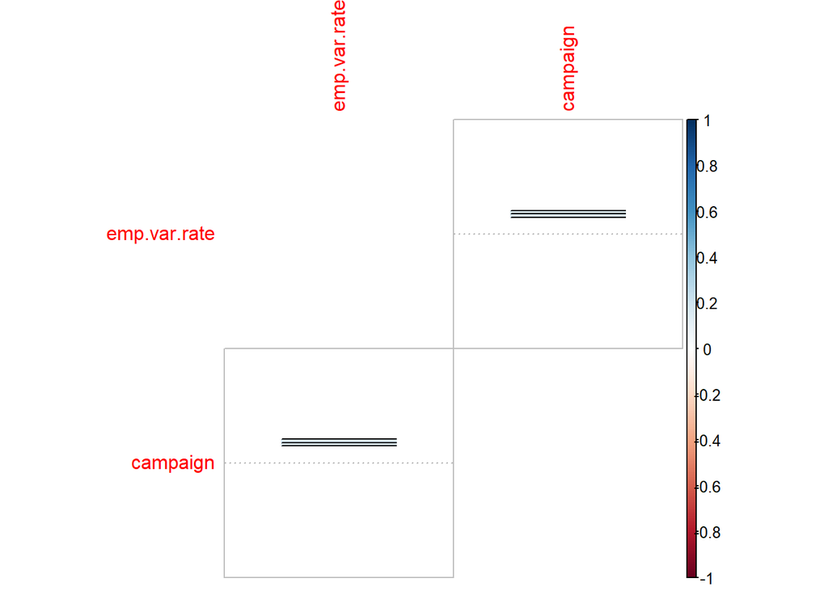

```r
#Constructing the correlation plot with confidence intervals
corrplot::corrplot(var_corr, number.digits=2,
                   low = test.conf.interval$lowCI,
                   up = test.conf.interval$uppCI,
                   plotCI = "rect",
                  diag = F)
```

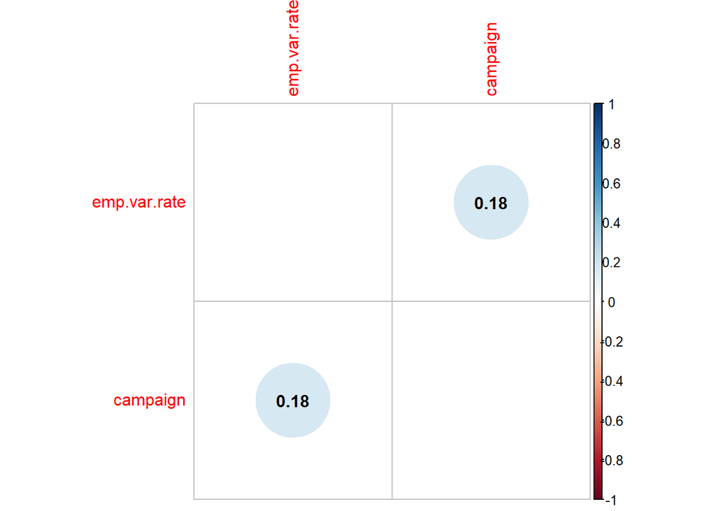

```r
#Constructing the correlation plot with correlation measures
corrplot::corrplot(var_corr, number.digits=2,
                   addCoef.col = "black", diag = F)
```

#### Numeric Summary Statistics When Grouping By Loan

If we group by loan then perform the summary statistics:

```r
#Summary statistics with regard to loan variable
summ.stats.loan = bank.2 %>%
  group_by(loan) %>%
  dplyr::select(.,c(emp.var.rate, campaign)) %>%
  summarise_all(., list(avg = mean, stan.dev = sd, minimum = min,
                        median.cal = median, maximum = max),
                na.rm = T)
summ.stats.loan = summ.stats.loan[1:2,]
```

```r
print(summ.stats.loan)
```

```
## # A tibble: 2 x 11
##   loan  emp.var.rate_avg campaign_avg emp.var.rate_stan.dev campaign_stan.dev
##   <chr>            <dbl>        <dbl>                 <dbl>             <dbl>
## 1 no              0.0812         2.56                  1.56              2.66
## 2 yes             0.0814         2.40                  1.59              2.12
## # ... with 6 more variables: emp.var.rate_minimum <dbl>,
## #   campaign_minimum <int>, emp.var.rate_median.cal <dbl>,
## #   campaign_median.cal <int>, emp.var.rate_maximum <dbl>,
## #   campaign_maximum <int>
```

```r
# First and third quartiles with respect ot the loan variable
summ.stats.2.loan = bank.2 %>%
  group_by(loan) %>%
  dplyr::select(.,c(emp.var.rate, campaign)) %>%
  summarise_all(., list(first.quantile = quantile),
                na.rm = T, probs = 0.25)

summ.stats.2.loan = summ.stats.2.loan[1:2,]

summ.stats.3.loan = bank.2 %>%
  group_by(loan) %>%
  dplyr::select(.,c(emp.var.rate, campaign)) %>%
  summarise_all(., list(third.quantile = quantile),
                na.rm = T, probs = 0.75)

summ.stats.3.loan = summ.stats.3.loan[1:2,]
```

```r
print(summ.stats.2.loan)
```

```
## # A tibble: 2 x 3
##   loan  emp.var.rate_first.quantile campaign_first.quantile
##   <chr>                       <dbl>                   <dbl>
## 1 no                           -1.8                       1
## 2 yes                          -1.8                       1
```

```r
print(summ.stats.3.loan)
```

```
## # A tibble: 2 x 3
##   loan  emp.var.rate_third.quantile campaign_third.quantile
##   <chr>                       <dbl>                   <dbl>
## 1 no                            1.4                       3
## 2 yes                           1.4                       3
```

```r
#Combining previously created dataframes
summ.stats.org.loan = right_join(x=summ.stats.loan,
                                 y=summ.stats.2.loan,
                                by="loan")
summ.stats.org.loan = right_join(x=summ.stats.org.loan,
                                 y=summ.stats.3.loan,
                                by="loan")
```

```r
#Perfroming dataframe transpose
summ.stats.org.loan_transpose =data.table::transpose(summ.stats.org.loan)
row.names(summ.stats.org.loan_transpose) =names(summ.stats.org.loan)
names(summ.stats.org.loan_transpose) = c(paste("loan_",summ.stats.org.loan_transpose[1,1], sep=""),
                                         paste("loan_",summ.stats.org.loan_transpose[1,2], sep=""))
summ.stats.org.loan_transpose = summ.stats.org.loan_transpose[2:nrow(summ.stats.org.loan_transpose),]
```

Thus the resulting summary statistics for when potential clients have taken a loan previously (loan.yes), and when potential clients have not taken a loan previously (loan.no).

```r
print(summ.stats.org.loan_transpose)
```

```
##                                        loan_no           loan_yes
## emp.var.rate_avg            0.0811884144520752 0.0813533834586466
## campaign_avg                  2.56404896984174   2.39548872180451
## emp.var.rate_stan.dev         1.55905790470149   1.58991966813952
## campaign_stan.dev             2.65777592137831   2.12096053561178
## emp.var.rate_minimum                      -3.4               -3.4
## campaign_minimum                             1                  1
## emp.var.rate_median.cal                    1.1                1.1
## campaign_median.cal                          2                  2
## emp.var.rate_maximum                       1.4                1.4
## campaign_maximum                            35                 17
## emp.var.rate_first.quantile               -1.8               -1.8
## campaign_first.quantile                      1                  1
## emp.var.rate_third.quantile                1.4                1.4
## campaign_third.quantile                      3                  3
```

#### Numeric Summary Statistics When Grouping By Default

Grouping by default and getting summary statistics:

```r
#Getting summary statistics with respect to default variable
summ.stats.default = bank.2 %>%
  group_by(default) %>%
  dplyr::select(.,c(emp.var.rate, campaign)) %>%
  summarise_all(., list(avg = mean, stan.dev = sd,
                        minimum = min,
                        median.cal = median,
                        maximum = max),
                na.rm = T)
summ.stats.default = summ.stats.default[1:2,]
```

```r
print(summ.stats.default)
```

```
## # A tibble: 2 x 11
##   default emp.var.rate_avg campaign_avg emp.var.rate_stan.dev campaign_stan.dev
##   <chr>              <dbl>        <dbl>                 <dbl>             <dbl>
## 1 no               -0.0570         2.51                  1.60              2.58
## 2 yes              -0.1            2                    NA                NA
## # ... with 6 more variables: emp.var.rate_minimum <dbl>,
## #   campaign_minimum <int>, emp.var.rate_median.cal <dbl>,
## #   campaign_median.cal <int>, emp.var.rate_maximum <dbl>,
## #   campaign_maximum <int>
```

Finding the quantiles for the numeric data:

```r
summ.stats.2.default = bank.2 %>%
  group_by(default) %>%
  dplyr::select(.,c(emp.var.rate, campaign)) %>%
  summarise_all(., list(first.quantile = quantile),
                na.rm = T, probs = 0.25)

summ.stats.2.default = summ.stats.2.default[1:2,]

summ.stats.3.default = bank.2 %>%
  group_by(default) %>%
  dplyr::select(.,c(emp.var.rate, campaign)) %>%
  summarise_all(., list(third.quantile = quantile),
                na.rm = T, probs = 0.75)

summ.stats.3.default = summ.stats.3.default[1:2,]
```

```r
print(summ.stats.2.default)
```

```
## # A tibble: 2 x 3
##   default emp.var.rate_first.quantile campaign_first.quantile
##   <chr>                         <dbl>                   <dbl>
## 1 no                             -1.8                       1
## 2 yes                            -0.1                       2
```

```r
print(summ.stats.3.default)
```

```
## # A tibble: 2 x 3
##   default emp.var.rate_third.quantile campaign_third.quantile
##   <chr>                         <dbl>                   <dbl>
## 1 no                              1.4                       3
## 2 yes                            -0.1                       2
```

```r
summ.stats.org.default = right_join(x=summ.stats.default,
                                    y=summ.stats.2.default,
                                by="default")
summ.stats.org.default = right_join(x=summ.stats.org.default,
                                    y=summ.stats.3.default,
                                by="default")
```

```r
summ.stats.org.default_transpose =data.table::transpose(summ.stats.org.default)
row.names(summ.stats.org.default_transpose) =names(summ.stats.org.default)
names(summ.stats.org.default_transpose) = c(paste("default.",summ.stats.org.default_transpose[1,1], sep=""),
                                         paste("default.",summ.stats.org.default_transpose[1,2], sep=""))
summ.stats.org.default_transpose = summ.stats.org.default_transpose[2:nrow(summ.stats.org.default_transpose),]
```

```r
print(summ.stats.org.default_transpose)
```

```
##                                      default.no default.yes
## emp.var.rate_avg            -0.0569532428355958        -0.1
## campaign_avg                     2.510407239819           2
## emp.var.rate_stan.dev          1.60449986076168        <NA>
## campaign_stan.dev              2.57713771266694        <NA>
## emp.var.rate_minimum                       -3.4        -0.1
## campaign_minimum                              1           2
## emp.var.rate_median.cal                     1.1        -0.1
## campaign_median.cal                           2           2
## emp.var.rate_maximum                        1.4        -0.1
## campaign_maximum                             35           2
## emp.var.rate_first.quantile                -1.8        -0.1
## campaign_first.quantile                       1           2
## emp.var.rate_third.quantile                 1.4        -0.1
## campaign_third.quantile                       3           2
```

#### Numerical Summary Statistics When Grouping By Education

Grouping by education to get the relevant summary statistics:

```r
#Getting summary statistics with respect to eduction variable
summ.stats.education = bank.2 %>%
  group_by(education) %>%
  dplyr::select(.,c(emp.var.rate, campaign, pdays)) %>%
  summarise_all(., list(avg = mean, stan.dev = sd,
                        minimum = min,
                        median.cal = median,
                        maximum = max),
                na.rm = T)
summ.stats.education = summ.stats.education[1:(length(unique(bank.2$education))-1),]
```

```r
print(summ.stats.education)
```

```
## # A tibble: 7 x 16
##   education           emp.var.rate_avg campaign_avg pdays_avg emp.var.rate_stan~
##   <chr>                          <dbl>        <dbl>     <dbl>              <dbl>
## 1 basic.4y                     0.292           2.42      5.45               1.51
## 2 basic.6y                     0.271           2.65      2                  1.40
## 3 basic.9y                     0.183           2.35      5.64               1.46
## 4 high.school                 -0.00250         2.63      5.84               1.58
## 5 illiterate                  -2.9             4       NaN                 NA
## 6 professional.course          0.164           2.51      7.09               1.55
## 7 university.degree           -0.00973         2.58      5.31               1.62
## # ... with 11 more variables: campaign_stan.dev <dbl>, pdays_stan.dev <dbl>,
## #   emp.var.rate_minimum <dbl>, campaign_minimum <int>, pdays_minimum <dbl>,
## #   emp.var.rate_median.cal <dbl>, campaign_median.cal <dbl>,
## #   pdays_median.cal <dbl>, emp.var.rate_maximum <dbl>, campaign_maximum <int>,
## #   pdays_maximum <dbl>
```

Calculating the first and third quartiles of numerical data when grouping by education:

```r
summ.stats.2.education = bank.2 %>%
  group_by(education) %>%
  dplyr::select(.,c(emp.var.rate, campaign
                    )) %>%
  summarise_all(., list(first.quantile = quantile),
                na.rm = T, probs = 0.25)

summ.stats.2.education = summ.stats.2.education[1:(length(unique(bank.2$education))-1),]

summ.stats.3.education = bank.2 %>%
  group_by(education) %>%
  dplyr::select(.,c(emp.var.rate, campaign)) %>%
  summarise_all(., list(third.quantile = quantile),
                na.rm = T, probs = 0.75)

summ.stats.3.education = summ.stats.3.education[1:(length(unique(bank.2$education))-1),]
```

```r
print(summ.stats.2.education)
```

```
## # A tibble: 7 x 3
##   education           emp.var.rate_first.quantile campaign_first.quantile
##   <chr>                                     <dbl>                   <dbl>
## 1 basic.4y                                   -1.7                       1
## 2 basic.6y                                   -1.8                       1
## 3 basic.9y                                   -1.8                       1
## 4 high.school                                -1.8                       1
## 5 illiterate                                 -2.9                       4
## 6 professional.course                        -1.8                       1
## 7 university.degree                          -1.8                       1
```

```r
print(summ.stats.3.education)
```

```
## # A tibble: 7 x 3
##   education           emp.var.rate_third.quantile campaign_third.quantile
##   <chr>                                     <dbl>                   <dbl>
## 1 basic.4y                                    1.4                       3
## 2 basic.6y                                    1.4                       3
## 3 basic.9y                                    1.4                       3
## 4 high.school                                 1.4                       3
## 5 illiterate                                 -2.9                       4
## 6 professional.course                         1.4                       3
## 7 university.degree                           1.4                       3
```

```r
summ.stats.org.education = right_join(x=summ.stats.education,
                                      y=summ.stats.2.education,
                                by="education")
summ.stats.org.education = right_join(x=summ.stats.org.education,
                                      y=summ.stats.3.education,
                                by="education")
```

```r
summ.stats.org.education_transpose =data.table::transpose(summ.stats.org.education)
row.names(summ.stats.org.education_transpose) =names(summ.stats.org.education)
names(summ.stats.org.education_transpose) = summ.stats.education$education
summ.stats.org.eduation_transpose = summ.stats.org.education_transpose[c(-1),]
```

```r
print(summ.stats.org.eduation_transpose)
```

```
##                                      basic.4y          basic.6y
## emp.var.rate_avg            0.291841491841492 0.271052631578947
## campaign_avg                 2.42191142191142  2.64912280701754
## pdays_avg                    5.45454545454545                 2
## emp.var.rate_stan.dev        1.50528775559788  1.40142933229941
## campaign_stan.dev            2.15445313259463    2.611335695963
## pdays_stan.dev               3.20510955705531  1.73205080756888
## emp.var.rate_minimum                     -3.4              -3.4
## campaign_minimum                            1                 1
## pdays_minimum                               2                 0
## emp.var.rate_median.cal                   1.1               1.1
## campaign_median.cal                         2                 2
## pdays_median.cal                            6                 3
## emp.var.rate_maximum                      1.4               1.4
## campaign_maximum                           19                17
## pdays_maximum                              14                 3
## emp.var.rate_first.quantile              -1.7              -1.8
## campaign_first.quantile                     1                 1
## emp.var.rate_third.quantile               1.4               1.4
## campaign_third.quantile                     3                 3
##                                      basic.9y          high.school illiterate
## emp.var.rate_avg            0.183275261324042 -0.00249728555917484       -2.9
## campaign_avg                 2.34843205574913     2.63083604777416          4
## pdays_avg                    5.63636363636364     5.84210526315789        NaN
## emp.var.rate_stan.dev        1.45568599453141     1.57726519517694       <NA>
## campaign_stan.dev            2.32683472574338     2.95408417652637       <NA>
## pdays_stan.dev               3.10717644406388     2.80469023957576       <NA>
## emp.var.rate_minimum                     -3.4                 -3.4       -2.9
## campaign_minimum                            1                    1          4
## pdays_minimum                               2                    2        Inf
## emp.var.rate_median.cal                   1.1                  1.1       -2.9
## campaign_median.cal                         2                    2          4
## pdays_median.cal                            5                    6       <NA>
## emp.var.rate_maximum                      1.4                  1.4       -2.9
## campaign_maximum                           29                   35          4
## pdays_maximum                              11                   12       -Inf
## emp.var.rate_first.quantile              -1.8                 -1.8       -2.9
## campaign_first.quantile                     1                    1          4
## emp.var.rate_third.quantile               1.4                  1.4       -2.9
## campaign_third.quantile                     3                    3          4
##                             professional.course    university.degree
## emp.var.rate_avg               0.16392523364486 -0.00973101265822787
## campaign_avg                   2.51214953271028     2.58306962025316
## pdays_avg                      7.09090909090909     5.30769230769231
## emp.var.rate_stan.dev          1.55370389702896     1.62155666208388
## campaign_stan.dev              2.40149416193499     2.58187814707219
## pdays_stan.dev                 4.98482545817653     3.77459880700534
## emp.var.rate_minimum                       -3.4                 -3.4
## campaign_minimum                              1                    1
## pdays_minimum                                 3                    0
## emp.var.rate_median.cal                     1.1                  1.1
## campaign_median.cal                           2                    2
## pdays_median.cal                              6                    4
## emp.var.rate_maximum                        1.4                  1.4
## campaign_maximum                             23                   27
## pdays_maximum                                21                   18
## emp.var.rate_first.quantile                -1.8                 -1.8
## campaign_first.quantile                       1                    1
## emp.var.rate_third.quantile                 1.4                  1.4
## campaign_third.quantile                       3                    3
```

#### Numerical Summary Statistics with Respect to Subscribed Status (y)

Computing group summary statistics with respect to y:

```r
#Getting summary statistics with respect to y
summ.stats.y = bank.2 %>%
  group_by(subscribed) %>%
  dplyr::select(.,c(emp.var.rate, campaign)) %>%
  summarise_all(., list(avg = mean, stan.dev = sd, minimum = min,
                        median.cal = median, maximum = max),
                na.rm = T)
```

```r
print(summ.stats.y)
```

```
## # A tibble: 2 x 11
##   subscribed emp.var.rate_avg campaign_avg emp.var.rate_stan.d~ campaign_stan.d~
##   <chr>                 <dbl>        <dbl>                <dbl>            <dbl>
## 1 no                    0.240         2.61                 1.48             2.67
## 2 yes                  -1.18          1.98                 1.64             1.37
## # ... with 6 more variables: emp.var.rate_minimum <dbl>,
## #   campaign_minimum <int>, emp.var.rate_median.cal <dbl>,
## #   campaign_median.cal <dbl>, emp.var.rate_maximum <dbl>,
## #   campaign_maximum <int>
```

Calculating the first and third quartiles of numerical data when grouping by subscribed:

```r
summ.stats.2.y = bank.2 %>%
  group_by(subscribed) %>%
  dplyr::select(.,c(emp.var.rate, campaign)) %>%
  summarise_all(., list(first.quantile = quantile),
                na.rm = T, probs = 0.25)


summ.stats.3.y = bank.2 %>%
  group_by(subscribed) %>%
  dplyr::select(.,c(emp.var.rate, campaign)) %>%
  summarise_all(., list(third.quantile = quantile),
                na.rm = T, probs = 0.75)
```

```r
print(summ.stats.2.y)
```

```
## # A tibble: 2 x 3
##   subscribed emp.var.rate_first.quantile campaign_first.quantile
##   <chr>                            <dbl>                   <dbl>
## 1 no                                -1.8                       1
## 2 yes                               -1.8                       1
```

```r
print(summ.stats.3.y)
```

```
## # A tibble: 2 x 3
##   subscribed emp.var.rate_third.quantile campaign_third.quantile
##   <chr>                            <dbl>                   <dbl>
## 1 no                                 1.4                     3
## 2 yes                                1.1                     2.5
```

```r
summ.stats.org.y = right_join(x=summ.stats.y,
                              y=summ.stats.2.y,
                                by="subscribed")
summ.stats.org.y = right_join(x=summ.stats.org.y,
                              y=summ.stats.3.y,
                                by="subscribed")
```

```r
summ.stats.org.y_transpose =data.table::transpose(summ.stats.org.y)
row.names(summ.stats.org.y_transpose) =names(summ.stats.org.y)
names(summ.stats.org.y_transpose) = c(paste("subscribed_",summ.stats.org.y_transpose[1,1], sep=""),
                                         paste("subscribed_",summ.stats.org.y_transpose[1,2], sep=""))
summ.stats.org.y_transpose = summ.stats.org.y_transpose[2:nrow(summ.stats.org.y_transpose),]
```

```r
print(summ.stats.org.y_transpose)
```

```
##                                 subscribed_no    subscribed_yes
## emp.var.rate_avg            0.240185387131952 -1.17738359201774
## campaign_avg                 2.60577971646674    1.980044345898
## emp.var.rate_stan.dev        1.48129844076496  1.63861005641203
## campaign_stan.dev            2.67083131542694  1.37017468400775
## emp.var.rate_minimum                     -3.4              -3.4
## campaign_minimum                            1                 1
## emp.var.rate_median.cal                   1.1              -1.8
## campaign_median.cal                         2                 2
## emp.var.rate_maximum                      1.4               1.4
## campaign_maximum                           35                11
## emp.var.rate_first.quantile              -1.8              -1.8
## campaign_first.quantile                     1                 1
## emp.var.rate_third.quantile               1.4               1.1
## campaign_third.quantile                     3               2.5
```

#### Examining Emp.var.rate and Subscribed Status Using a Simple Logistic Regression model:

```r
bank.2.convert.labels = bank.2 %>% mutate(subscribed = ifelse( subscribed == "yes", 1, 0))
```

```r
emp.var.rate.glm = glm(subscribed ~ emp.var.rate, data=bank.2.convert.labels, family = binomial)
```

```r
summary(emp.var.rate.glm)
```

```
##
## Call:
## glm(formula = subscribed ~ emp.var.rate, family = binomial, data = bank.2.convert.labels)
##
## Deviance Residuals:
##    Min      1Q  Median      3Q     Max
## -0.971  -0.440  -0.322  -0.298   2.506
##
## Coefficients:
##              Estimate Std. Error z value Pr(>|z|)
## (Intercept)   -2.3398     0.0609   -38.4   <2e-16 ***
## emp.var.rate  -0.5393     0.0323   -16.7   <2e-16 ***
## ---
## Signif. codes:  0 '***' 0.001 '**' 0.01 '*' 0.05 '.' 0.1 ' ' 1
##
## (Dispersion parameter for binomial family taken to be 1)
##
##     Null deviance: 2845.8  on 4118  degrees of freedom
## Residual deviance: 2539.9  on 4117  degrees of freedom
## AIC: 2544
##
## Number of Fisher Scoring iterations: 5
```

```r
confint(emp.var.rate.glm)
```

```
##               2.5 % 97.5 %
## (Intercept)  -2.462 -2.223
## emp.var.rate -0.603 -0.477
```

According to results given by the logistic regression model, emp.var.rate may have a relationship with the with the value of y considering the confidence interval for emp.var.rate excludes 0, satisfying the significance test at the 95% significance level.

#### Examining Subscribed Status and campaign Using a Simple Logistic Regression Model:

```r
campaign.glm = glm(subscribed ~ campaign,
                   data=bank.2.convert.labels,
                   family = binomial)
```

```r
summary(campaign.glm)
```

```
##
## Call:
## glm(formula = subscribed ~ campaign, family = binomial, data = bank.2.convert.labels)
##
## Deviance Residuals:
##    Min      1Q  Median      3Q     Max
## -0.528  -0.528  -0.490  -0.422   2.648
##
## Coefficients:
##             Estimate Std. Error z value Pr(>|z|)
## (Intercept)  -1.7440     0.0816  -21.37  < 2e-16 ***
## campaign     -0.1574     0.0320   -4.92  8.8e-07 ***
## ---
## Signif. codes:  0 '***' 0.001 '**' 0.01 '*' 0.05 '.' 0.1 ' ' 1
##
## (Dispersion parameter for binomial family taken to be 1)
##
##     Null deviance: 2845.8  on 4118  degrees of freedom
## Residual deviance: 2812.9  on 4117  degrees of freedom
## AIC: 2817
##
## Number of Fisher Scoring iterations: 5
```

```r
confint(campaign.glm)
```

```
##              2.5 %  97.5 %
## (Intercept) -1.903 -1.5832
## campaign    -0.223 -0.0977
```

According to results given by the logistic regression model, campaign may have a relationship with the with the value of y considering the confidence interval for campaign excludes 0, satisfying the 95% significance level.

#### Examining Subscribed Status and Previous.contact Using a Chi-Squared Test:

```r
subscribed_by_prev.contact.table = table(factor(bank.2$subscribed), factor(bank.2$previous.contact))
```

```r
chisq.test(subscribed_by_prev.contact.table)
```

```
##
##  Pearson's Chi-squared test with Yates' continuity correction
##
## data:  subscribed_by_prev.contact.table
## X-squared = 448, df = 1, p-value <2e-16
```

According to the results of the Chi-Squared Test, the variable previous.contact may have a relationship with y as the p-value is statistically significant satisfying the 95% significance level as the p-value is close to 0 with a $\chi^{2} = 448$ and 1 degree of freedom.

#### Examining Subscribed Status and Education Using a Chi-Squared Test:

```r
subscribed_by_education.table = table(factor(bank.2$subscribed), factor(bank.2$education))
```

```r
chisq.test(subscribed_by_education.table)
```

```
##
##  Pearson's Chi-squared test
##
## data:  subscribed_by_education.table
## X-squared = 19, df = 6, p-value = 0.005
```

#### Examining Subscribed Status and Loan Using a Chi-Squared Test:

```r
subscribed_by_loan.table = table(factor(bank.2$subscribed), factor(bank.2$loan))
```

```r
chisq.test(subscribed_by_loan.table)
```

```
##
##  Pearson's Chi-squared test with Yates' continuity correction
##
## data:  subscribed_by_loan.table
## X-squared = 0.4, df = 1, p-value = 0.5
```

According the Chi-Squared test with a $\chi^{2}$ value of 0.4 and 1 degree of freedom, the resulting p-value is 0.5 which is not statistically significant at the 95% signficance level. The variables subscribed status (y) and loan seem to be independent.

#### Examining Subscribed Status and Default Using a Chi-Squared Test:

```r
subscribed_by_default.table = table(factor(bank.2$subscribed), factor(bank.2$default))
```

```r
chisq.test(subscribed_by_default.table)
```

```
##
##  Pearson's Chi-squared test with Yates' continuity correction
##
## data:  subscribed_by_default.table
## X-squared = 5e-27, df = 1, p-value = 1
```

## Data Visualizations to Complement Summary Statistics

### Research Question 1 Visualizations

#### Stacked Bar Graph for Marital Status and Default Status:

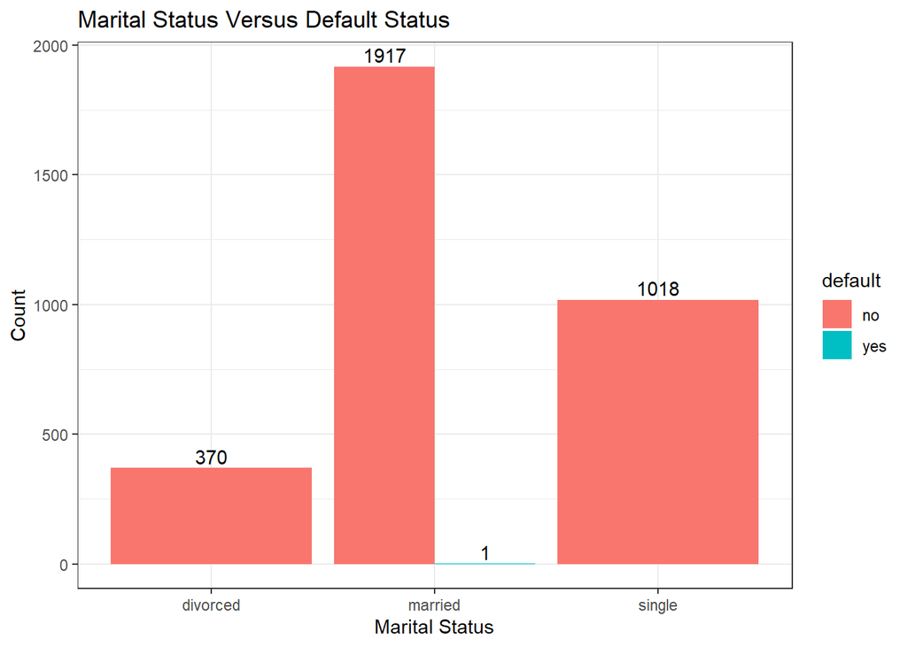

```r
bank.2 %>%
  dplyr::select(.,marital, default) %>%
  na.omit() %>%
  group_by(., marital, default) %>%
  count() %>%
  rename(.,frequency = "n") %>%
  ggplot(.,aes(x = factor(marital), y =frequency, fill=default)) +
  geom_bar(position="dodge", stat = "identity") +
  labs(title = "Marital Status Versus Default Status",
       x = "Marital Status", y ="Count") +
  theme_bw() +
  geom_text(aes(label = frequency),
            vjust = -0.3,
            position = position_dodge(.9))
```

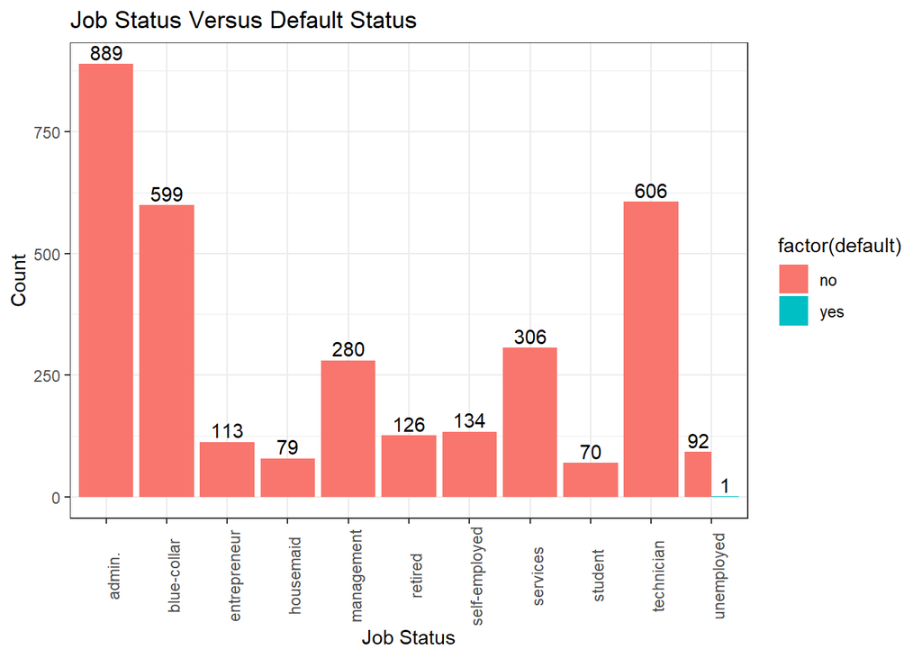

```r
bank.2 %>%
  dplyr::select(.,job, default) %>%
  na.omit() %>%
  group_by(., job, default) %>%
  count() %>%
  rename(.,frequency = "n") %>%
  ggplot(.,aes(x = factor(job), y =frequency, fill=factor(default))) +
  geom_bar(position="dodge", stat = "identity")+
  labs(title = "Job Status Versus Default Status",
       x = "Job Status", y ="Count") +
  theme_bw()+
  theme(axis.text.x = element_text(angle=90)) +
  geom_text(aes(label = frequency),
            vjust = -0.3,
            position = position_dodge(.9))
```

As could be observed when computing the grouped job status and default status beforehand, the variables appear to a relationship with one another one another. Additionally for each job status, the majority of potential clients have not currently be in default with their credit at the time of contact.